# Introduction_to_Quarto

Author

David Nganga

Published

September 11, 2026

Question:

➡️ Create one document for two of the most common formats: HTML and Word. Render each of the three documents.

- How does the output differ?

  Answer:

  Html : render output as .html file. the output can interact with web. html also enables interactive features like interactive data visualization.

  word : renders .docx file which can only open and edit on desktop. word output are static images
- Looking at the YAML at the top of the document, how does the input differ?

  Answer:The input between the two is different int in format. for html we get “format:html” and for word we get “format: docx”.

## **Markdown**

Markdown is a lightweight set of conventions for formatting plain text files.

### **Headings**

Headings and subheadings can be included in a file to organize the document. make sure to leave a space between the # and heading.

#1st Level Header

##2nd Level Header

###3rd Level Header

Activity_1:

Include a first-level header, second-level header, and third-level header in your document naming them Section 1, Subsection 1.1, and Subsubsection 1.1.1, respectively.

Solution:

# Section 1

## Subsection 1.1,

### Subsubsection 1.1.1

## Including R code chunks

R code chunks in R are include by pressing “Option+ Command + i”

### **Links and Images**

Hyperlinks and external images or GIFs can be included in Quarto documents as well.

### Hyperlinks

[linked phrase](http://example.com+) “if i remove the + sign, the link name will be shown as below.”

[linked phrase](http://example.com)

Activity_2:

Include a hyperlink linking to the Google homepage.

Solution:

[Google Homegage](https://www.google.com/?client=safari&channel=mac_bm+). ” if i remove the + sign, the link name will be shown as below.”

[Google Homepage](https://www.google.com/?client=safari&channel=mac_bm)

### images

Always right click an image from a website to copy the path (image address).

[Image caption text](path/to/img.png)

Activity_3:

crating link for the image of the “World cup winner 2026”

[World cup winner 2026](https://static.time.com/v3/assets/bltea6093859af6183b/blta99a3b5fab853572/6a5d94ca7cb8c6203481b3e7/GettyImages-2286250745.jpg?branch=production&width=1440&quality=75&auto=webp&crop=3:2)

### **Text Formatting**

Basic formatting of text, such as italicizing, bolding, superscripts, and subscripts can be implemented as well.

| Raw text input | Rendered output |
| --- | --- |
| *italic* | *italic* |
| **bold** | **bold** |
| `code` | code |
| superscript^2^ | superscript2 |
| subscript~2~ | subscript2 |

### Activity_4:

➡️ Include an italicized word or phrase.

Solution: *On July 19, 2026 Spain won world cup finals defeating Argentina 1-0*

➡️ Include a bold word or phrase.

Solution: **On July 19, 2026 Spain won world cup finals defeating Argentina 1-0**

➡️ Include a word styled showing it is code.

Solution: On July 19, 2026 `Spain` won world cup finals defeating Argentina 1-0

➡️ Include a superscript and a subscript.

Solution: On July 19<sup>th</sup>, 2026 `Spain` won world cup finals defeating Argentina <sub>1-0</sub>.

## **Code Chunks**

adding **code chunks** to the file, allows us to run R code inside our document:

There are several ways to insert a code chunk:

1. The keyboard shortcut Cmd/Ctrl + Alt + I (recommended)
2. The “Insert” button icon in the editor toolbar (top right).
3. By manually typing the chunk delimiters

Activity_5:

➡️ Add a new code chunk at the bottom of the Quarto document, naming the chunk uptown-chunk by including **#| label: uptown-chunk** as the first line inside the code chunk.

Solution:

```r
scores <- c(3,5,2,8)
mean(scores)
```

```
[1] 4.5
```

Activity_6:

➡️ In the code chunk, use the include_graphics() function from the knitr package to include the image at the following URL:https://github.com/dilernia/STA418-518/blob/main/uptownFunk2.png?raw=true. Note that the URL should be enclosed in quotes when calling the include_graphics() function.

solution:

```r
### Use of knitr::include_graphics()
knitr::include_graphics("https://raw.githubusercontent.com/dilernia/STA418-518/refs/heads/main/uptownFunk2.png")
```

[output not shown]

**Why use `knitr::include_graphics()`?**

- **Consistency:**It handles pathing seamlessly across different output formats (like HTML, PDF, and Word).
- **Quarto Integration:**It allows you to use chunk options like #| out.width: “80%”`or`#| fig.align: “center”`to control how the image looks in your final document.

Activity_7

➡️ Modify uptown-chunk by setting the echo chunk option to be false by including **#| echo: false** immediately below the line with **#| label: uptown-chunk**.

solution:

```r
### Use of knitr::include_graphics()
knitr::include_graphics("https://raw.githubusercontent.com/dilernia/STA418-518/refs/heads/main/uptownFunk2.png")
```

[output not shown]

note:during the output, the code will be hidden and only image will output set by #| echo: false

Activity 8.

Specify and toggle the include and eval chunk options for the uptown-chunk code chunk and see what happens. Note that some of the code chunk options for controlling the dimensions of figures only apply for graphics produced in code chunks, but not externally included images.

solution:

```r
#| eval: true
#| include: false
### Use of knitr::include_graphics()
knitr::include_graphics("https://raw.githubusercontent.com/dilernia/STA418-518/refs/heads/main/uptownFunk2.png")
```

```r
#| eval: true
#| include: true
### Use of knitr::include_graphics()
knitr::include_graphics("https://raw.githubusercontent.com/dilernia/STA418-518/refs/heads/main/uptownFunk2.png")
```

[output not shown]

### Chunk Option Behaviour

| `eval` | `include` | Does code execute? | Is code shown in report? | Are results/images shown? | Common Use Case |
| --- | --- | --- | --- | --- | --- |
| **`true`** | **`true`** | Yes | Depends on `echo` | Yes | Standard active chunk for plots/text/images. |
| **`true`** | **`false`** | Yes | No | No | Quiet data setup, loading libraries/scripts. |
| **`false`** | **`true`** | No | Depends on `echo` | No | Displaying example code without running it. |
| **`false`** | **`false`** | No | No | No | Deactivating/omitting chunk from document. |

### Customizing the YAML (at the top of the Quarto document)

-–  
title: “Document title”  
author: “Author name”  
date: today  
format:  
html:  
self-contained: true  
embed-resources: true  
execute:  
eval: true # Evaluate code  
echo: true # Show code  
warning: false # Suppress warnings  
message: false # Suppress messages  
-–

### Including plots

first, nstall.packages(‘tidyverse’) to the Console if not installed.

excercise: plotting a scatter plot on storms ⛈️ between 1975 and 2021 from the National Oceanic and Atmospheric Administration (NOAA) data.

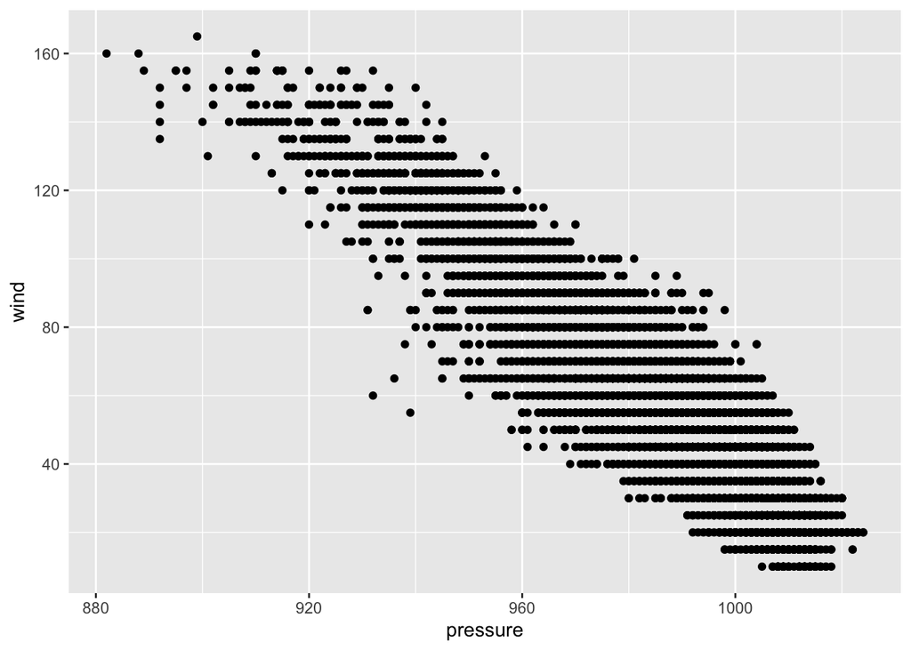

```r
library(tidyverse)
# Load storms data set
data(storms)

storms |> ggplot(aes(x = pressure, y = wind)) +
  geom_point()
```

Activity 9.

Toggle the out-height, out-width, and fig-align chunk options, exploring their effect on the output document.

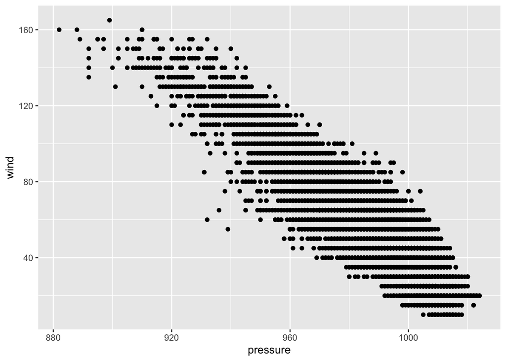

```r
library(tidyverse)
# Load storms data set
data(storms)

storms |> ggplot(aes(x = pressure, y = wind)) +
  geom_point()
```

### Inline Code

```r
xbar<-2
se<-1.3
```

The 95% confidence interval for the mean is (-0.548, 4.548)

Activity 10.

➡️ Include a chunk of R code and after that in-line R code at the bottom of the document to reproduce the sentence containing the confidence interval results above.

solution:

A.chunk R code

```r
xbar<-4
se<-2.3
confidence_interval<- c( (xbar - 1.96 * se), (xbar - 1.96 * se) )
confidence_interval
```

```
[1] -0.508 -0.508
```

B. In-line code

### Tables

Continueing with the storms data set looking at the four largest sustained wind speeds recorded for different storms.

```r
#Largest sustained wind speeds recorded
storms_summary<- storms |>
  group_by(name, year) |>
  summarize(max_wind_knots =max(wind)) |>
  ungroup() |>
  slice_max(max_wind_knots, n=4)

library(knitr)
storms_summary |>
  kable()
```

| name | year | max_wind_knots |
| --- | --- | --- |
| Allen | 1980 | 165 |
| Dorian | 2019 | 160 |
| Gilbert | 1988 | 160 |
| Wilma | 2005 | 160 |

#### *kable() from the knitr package*

The kable() function includes tables in Quarto documents for PDF, HTML, and Word outputs.

### customizing table captions

```r
#| tbl-cap: ‘A custom table caption’
```

#### *flextable() from the flextable package*

flextable() function from flextable package displays tables for all output formats in a more consistent manner, with a large number of methods for customization that work for all output formats as shown Table 1

```r
library(flextable)

storms_summary |>
  flextable() |>
  colformat_double(big.mark="", digits=0) |>
  autofit()
```

| name | year | max_wind_knots |
| --- | --- | --- |
| Allen | 1980 | 165 |
| Dorian | 2019 | 160 |
| Gilbert | 1988 | 160 |
| Wilma | 2005 | 160 |

### get() from the gt package

get() function from get package has a wide range of formatting options, including conditional formatting and group-wise summary statistics. It is most easily used with HTML as the output format for Quarto, but not as easily for PDF or Word output when further customizing the table.

```r
library(gt)

storms_summary |>
  gt()
```

| name | year | max_wind_knots |
| --- | --- | --- |
| Allen | 1980 | 165 |
| Dorian | 2019 | 160 |
| Gilbert | 1988 | 160 |
| Wilma | 2005 | 160 |

### Table Themes

customizing aspects about tables displayed in Quarto using flextable () function.

```r
# Displaying flextable with tron theme
#| label: storms_summary
storms_summary |>
  flextable() |>
  autofit() |>
  theme_tron()
```

| name | year | max_wind_knots |
| --- | --- | --- |
| Allen | 1,980 | 165 |
| Dorian | 2,019 | 160 |
| Gilbert | 1,988 | 160 |
| Wilma | 2,005 | 160 |

Activity 11:

➡️ Display the storms_summary table applying a complete theme different than the one used above using the flextable() function by viewing the available themes here:

solution:

```r
library(flextable)
# Displaying flextable with a clean zebra theme
storms_summary |>
  flextable() |>
  autofit() |>
  theme_zebra()
```

| name | year | max_wind_knots |
| --- | --- | --- |
| Allen | 1,980 | 165 |
| Dorian | 2,019 | 160 |
| Gilbert | 1,988 | 160 |
| Wilma | 2,005 | 160 |

Activity 12.

➡️ Display the storms_summary table applying a complete theme different than the one used above using the gt() function and the [gtExtras](https://jthomasmock.github.io/gtExtras/reference/index.html) R package by viewing the available themes here: https://jthomasmock.github.io/gtExtras/reference/index.html

```r
library(gt)
library(gtExtras)

# Combine everything into a single, connected pipeline
storms_summary |>
  gt(id = "tbl-custom") |>
  gt_theme_dot_matrix()
```

| name | year | max_wind_knots |
| --- | --- | --- |
| Allen | 1980 | 165 |
| Dorian | 2019 | 160 |
| Gilbert | 1988 | 160 |
| Wilma | 2005 | 160 |